# Who Gets to Speak on Screen?

## A 44-Year Look at the Bechdel Test in Hollywood Films

**DS 220, Project II** | Min Liu | Spring 2026

> *The Bechdel Test asks whether a film has two named women who talk to each other about something other than a man. I use it as a lens on 1,794 films from 1970 to 2013.*

## 1. Problem Space

The Bechdel Test is a three-question check on whether a film treats women as full characters. I am asking whether Hollywood has gotten better at this over time, and whether doing so is good or bad for business. Audiences, executives, filmmakers, and advocacy groups all care for different reasons.

The data covers US theatrical releases from 1970 to 2013, with results from [bechdeltest.com](https://bechdeltest.com/) and financials from [The Numbers](https://www.the-numbers.com/), aggregated by FiveThirtyEight.

## 2. Questions to Address

1. Has the pass rate risen, fallen, or stayed flat?
2. Which decade was best, which was worst?
3. Do bigger-budget films pass less often?
4. Do passing films earn more, less, or the same on a per-budget basis?
5. Is the ROI distribution shape different for passing and failing films?
6. What is the most common failure mode?
7. Is the "two named women" floor shrinking?
8. Do representation and money move together over time?

## 3. The Dataset

Source: FiveThirtyEight's [Bechdel Test dataset](https://github.com/fivethirtyeight/data/tree/master/bechdel), released with Walt Hickey's 2014 article *"The Dollar-and-Cents Case Against Hollywood's Exclusion of Women."* Each row is one film.

| Column | Meaning |
| --- | --- |
| `year`, `title`, `imdb` | Release year, title, IMDb id |
| `clean_test` | `ok`, `dubious`, `men`, `notalk`, or `nowomen` |
| `binary` | `PASS` or `FAIL` |
| `budget_2013$`, `domgross_2013$`, `intgross_2013$` | Inflation-adjusted to 2013 USD |

I use the inflation-adjusted columns throughout.

## 4. Setup

```python
import pandas as pd
import numpy as np
import matplotlib.pyplot as plt
import seaborn as sns
import warnings, os

warnings.filterwarnings('ignore')

# Visual defaults so charts render well in the published HTML.
sns.set_theme(style='whitegrid', context='talk')
plt.rcParams.update({
    'figure.facecolor': 'white',
    'axes.facecolor':   'white',
    'figure.dpi':       110,
    'savefig.dpi':      110,
    'font.family':      'DejaVu Sans',
    'axes.titleweight': 'bold',
    'axes.titlesize':   14,
    'axes.labelsize':   11,
})

# Single palette: warm = pass, cool = fail, slate = neutral.
PASS_COLOR = '#2a9d8f'
FAIL_COLOR = '#e76f51'
NEUTRAL    = '#264653'

print('Setup complete.')
```

```
Setup complete.
```

The next cell loads the CSV in Colab or locally.

```python
# Colab: prompt to upload the CSV. Skipped silently when running locally.
try:
    from google.colab import files
    if not (os.path.exists('movies.csv') or os.path.exists('data/movies.csv')):
        uploaded = files.upload()
except (ImportError, ModuleNotFoundError):
    pass

if os.path.exists('data/movies.csv'):
    df = pd.read_csv('data/movies.csv')
elif os.path.exists('movies.csv'):
    df = pd.read_csv('movies.csv')
else:
    raise FileNotFoundError('movies.csv not found.')

print(f'Loaded {len(df):,} films from {df["year"].min()} to {df["year"].max()}.')
```

```
Loaded 1,794 films from 1970 to 2013.
```

## 5. Load and Inspect

Quick looks at the raw data before any analysis.

```python
df.head()
```

|  | year | imdb | title | test | clean_test | binary | budget | domgross | intgross | code | budget_2013$ | domgross_2013$ | intgross_2013$ | period code | decade code |
| --- | --- | --- | --- | --- | --- | --- | --- | --- | --- | --- | --- | --- | --- | --- | --- |
| 0 | 2013 | tt1711425 | 21 &amp; Over | notalk | notalk | FAIL | 13000000 | 25682380.0 | 42195766.0 | 2013FAIL | 13000000 | 25682380.0 | 42195766.0 | 1.0 | 1.0 |
| 1 | 2012 | tt1343727 | Dredd 3D | ok-disagree | ok | PASS | 45000000 | 13414714.0 | 40868994.0 | 2012PASS | 45658735 | 13611086.0 | 41467257.0 | 1.0 | 1.0 |
| 2 | 2013 | tt2024544 | 12 Years a Slave | notalk-disagree | notalk | FAIL | 20000000 | 53107035.0 | 158607035.0 | 2013FAIL | 20000000 | 53107035.0 | 158607035.0 | 1.0 | 1.0 |
| 3 | 2013 | tt1272878 | 2 Guns | notalk | notalk | FAIL | 61000000 | 75612460.0 | 132493015.0 | 2013FAIL | 61000000 | 75612460.0 | 132493015.0 | 1.0 | 1.0 |
| 4 | 2013 | tt0453562 | 42 | men | men | FAIL | 40000000 | 95020213.0 | 95020213.0 | 2013FAIL | 40000000 | 95020213.0 | 95020213.0 | 1.0 | 1.0 |

```python
df.info()
```

```
<class 'pandas.core.frame.DataFrame'>
RangeIndex: 1794 entries, 0 to 1793
Data columns (total 15 columns):
 #   Column          Non-Null Count  Dtype
---  ------          --------------  -----
 0   year            1794 non-null   int64
 1   imdb            1794 non-null   object
 2   title           1794 non-null   object
 3   test            1794 non-null   object
 4   clean_test      1794 non-null   object
 5   binary          1794 non-null   object
 6   budget          1794 non-null   int64
 7   domgross        1777 non-null   float64
 8   intgross        1783 non-null   float64
 9   code            1794 non-null   object
 10  budget_2013$    1794 non-null   int64
 11  domgross_2013$  1776 non-null   float64
 12  intgross_2013$  1783 non-null   float64
 13  period code     1615 non-null   float64
 14  decade code     1615 non-null   float64
dtypes: float64(6), int64(3), object(6)
memory usage: 210.4+ KB
```

```python
df[['budget','domgross','intgross','budget_2013$','domgross_2013$','intgross_2013$']].describe().round(0)
```

|  | budget | domgross | intgross | budget_2013$ | domgross_2013$ | intgross_2013$ |
| --- | --- | --- | --- | --- | --- | --- |
| count | 1794.0 | 1777.0 | 1.783000e+03 | 1794.0 | 1.776000e+03 | 1.783000e+03 |
| mean | 44826463.0 | 69132048.0 | 1.503857e+08 | 55464608.0 | 9.517478e+07 | 1.978380e+08 |
| std | 48186026.0 | 80367310.0 | 2.103353e+08 | 54918636.0 | 1.259653e+08 | 2.835079e+08 |
| min | 7000.0 | 0.0 | 8.280000e+02 | 8632.0 | 8.990000e+02 | 8.990000e+02 |
| 25% | 12000000.0 | 16311571.0 | 2.612947e+07 | 16068918.0 | 2.054659e+07 | 3.323260e+07 |
| 50% | 28000000.0 | 42194060.0 | 7.648246e+07 | 36995786.0 | 5.599364e+07 | 9.623964e+07 |
| 75% | 60000000.0 | 93354918.0 | 1.898509e+08 | 78337905.0 | 1.216784e+08 | 2.414790e+08 |
| max | 425000000.0 | 760507625.0 | 2.783919e+09 | 461435929.0 | 1.771683e+09 | 3.171931e+09 |

### Cleaning

```python
for col in ['domgross', 'intgross', 'domgross_2013$', 'intgross_2013$']:
    df[col] = pd.to_numeric(df[col], errors='coerce')

df['title'] = df['title'].str.replace('&amp;', '&', regex=False)
df['decade'] = (df['year'] // 10) * 10

df['worldgross_2013$'] = df['domgross_2013$'].fillna(0) + df['intgross_2013$'].fillna(0)
df['roi'] = (df['worldgross_2013$'] - df['budget_2013$']) / df['budget_2013$']

print('Cleaned. Missing values per critical column:')
df[['budget_2013$', 'domgross_2013$', 'intgross_2013$', 'binary', 'clean_test']].isna().sum()
```

```
Cleaned. Missing values per critical column:
```

```
budget_2013$       0
domgross_2013$    18
intgross_2013$    11
binary             0
clean_test         0
dtype: int64
```

## 6. Exploratory Data Analysis

Sample size by year, the Bechdel bucket distribution, and the financial variables on a log scale.

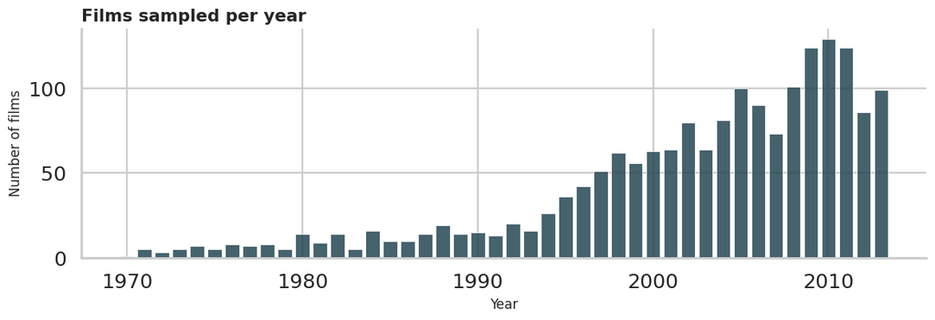

```python
films_per_year = df.groupby('year').size()

fig, ax = plt.subplots(figsize=(11, 4))
ax.bar(films_per_year.index, films_per_year.values,
       color=NEUTRAL, alpha=0.85, edgecolor='white', linewidth=0.6)
ax.set_title('Films sampled per year', fontsize=14, loc='left')
ax.set_xlabel('Year'); ax.set_ylabel('Number of films')
ax.spines[['right', 'top']].set_visible(False)
plt.tight_layout()
plt.show()
```

Years before 1990 are sparse, so I read the early decades cautiously.

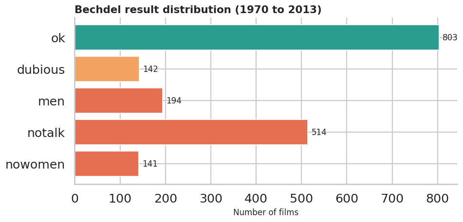

```python
order = ['ok', 'dubious', 'men', 'notalk', 'nowomen']
counts = df['clean_test'].value_counts().reindex(order)

fig, ax = plt.subplots(figsize=(9, 4.5))
colors = [PASS_COLOR, '#f4a261', FAIL_COLOR, FAIL_COLOR, FAIL_COLOR]
ax.barh(order, counts.values, color=colors, edgecolor='white', linewidth=1.1)
for i, v in enumerate(counts.values):
    ax.text(v + 8, i, f'{v:,}', va='center', fontsize=11)
ax.set_title('Bechdel result distribution (1970 to 2013)', fontsize=14, loc='left')
ax.set_xlabel('Number of films')
ax.spines[['right', 'top']].set_visible(False)
ax.invert_yaxis()
plt.tight_layout()
plt.show()
```

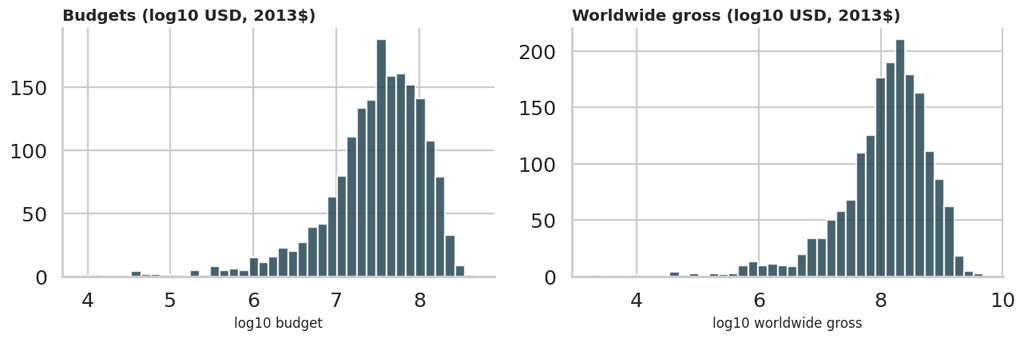

```python
fig, axes = plt.subplots(1, 2, figsize=(12, 4.2))
axes[0].hist(np.log10(df['budget_2013$'].dropna()), bins=40, color=NEUTRAL, alpha=0.85, edgecolor='white')
axes[0].set_title('Budgets (log10 USD, 2013$)', fontsize=13, loc='left')
axes[0].set_xlabel('log10 budget')
axes[1].hist(np.log10(df['worldgross_2013$'].replace(0, np.nan).dropna()), bins=40, color=NEUTRAL, alpha=0.85, edgecolor='white')
axes[1].set_title('Worldwide gross (log10 USD, 2013$)', fontsize=13, loc='left')
axes[1].set_xlabel('log10 worldwide gross')
for ax in axes:
    ax.spines[['right', 'top']].set_visible(False)
plt.tight_layout()
plt.show()
```

Both distributions look roughly bell shaped on the log scale, so a log axis is the right choice for later charts.

## 7. Q1, Pass rate over time

I plot the annual rate plus a 3-year rolling mean, since many years have small samples.

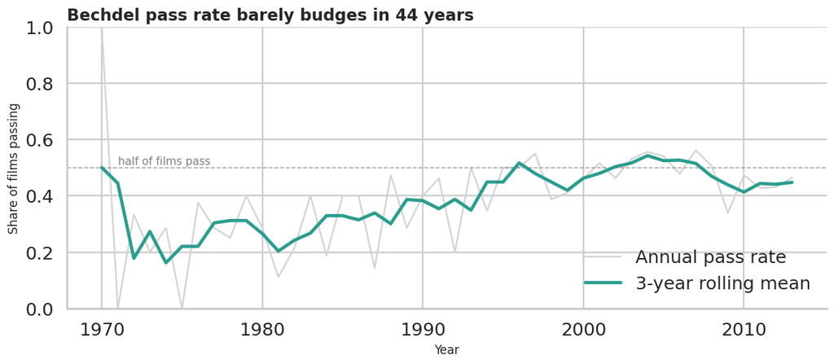

```
Avg pass rate 1970 to 1979: 31%
Avg pass rate 2004 to 2013: 48%
```

```python
yearly = df.groupby('year')['binary'].apply(lambda s: (s == 'PASS').mean())
yearly_smoothed = yearly.rolling(3, center=True, min_periods=1).mean()

fig, ax = plt.subplots(figsize=(11, 5))
ax.plot(yearly.index, yearly.values, '-', color='lightgray', linewidth=1.5, label='Annual pass rate', zorder=2)
ax.plot(yearly_smoothed.index, yearly_smoothed.values, '-', color=PASS_COLOR, linewidth=3, label='3-year rolling mean', zorder=3)
ax.axhline(0.5, ls='--', color='gray', linewidth=1, alpha=0.7)
ax.text(1971, 0.51, 'half of films pass', color='gray', fontsize=10)
ax.set_ylim(0, 1)
ax.set_xlabel('Year'); ax.set_ylabel('Share of films passing')
ax.set_title('Bechdel pass rate barely budges in 44 years', fontsize=15, loc='left', fontweight='bold')
ax.legend(loc='lower right', frameon=False)
ax.spines[['right', 'top']].set_visible(False)
plt.tight_layout()
plt.show()

early = yearly.loc[1970:1979].mean()
late = yearly.loc[2004:2013].mean()
print(f'Avg pass rate 1970 to 1979: {early:.0%}')
print(f'Avg pass rate 2004 to 2013: {late:.0%}')
```

## 8. Q2, Pass rate by decade

I keep sample size visible above each bar so a small-n decade does not mislead.

```python
decade_summary = (df.groupby('decade')['binary']
                     .agg(['count', lambda s: (s=='PASS').mean()])
                     .rename(columns={'<lambda_0>': 'pass_rate', 'count': 'n_films'}))
decade_summary['pass_rate_pct'] = (decade_summary['pass_rate'] * 100).round(1)
decade_summary
```

| decade | n_films | pass_rate | pass_rate_pct |
| --- | --- | --- | --- |
| 1970 | 54 | 0.259259 | 25.9 |
| 1980 | 125 | 0.288000 | 28.8 |
| 1990 | 337 | 0.436202 | 43.6 |
| 2000 | 840 | 0.486905 | 48.7 |
| 2010 | 438 | 0.449772 | 45.0 |

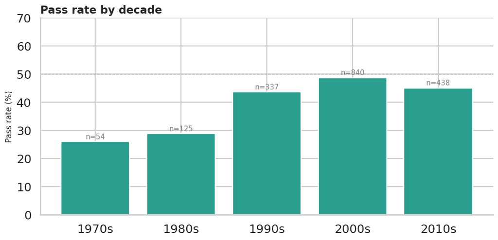

```python
fig, ax = plt.subplots(figsize=(10, 5))
bars = ax.bar(decade_summary.index.astype(str)+'s', decade_summary['pass_rate']*100,
              color=PASS_COLOR, edgecolor='white', linewidth=1.5)
for bar, n in zip(bars, decade_summary['n_films']):
    ax.text(bar.get_x()+bar.get_width()/2, bar.get_height()+1, f'n={n}', ha='center', fontsize=10, color='gray')
ax.axhline(50, ls='--', color='gray', linewidth=1, alpha=0.7)
ax.set_ylim(0, 70)
ax.set_ylabel('Pass rate (%)')
ax.set_title('Pass rate by decade', fontsize=15, loc='left', fontweight='bold')
ax.spines[['right', 'top']].set_visible(False)
plt.tight_layout()
plt.show()
```

## 9. Q3, Does budget predict passing?

A violin plot to compare the full budget distribution shape, not just summary numbers.

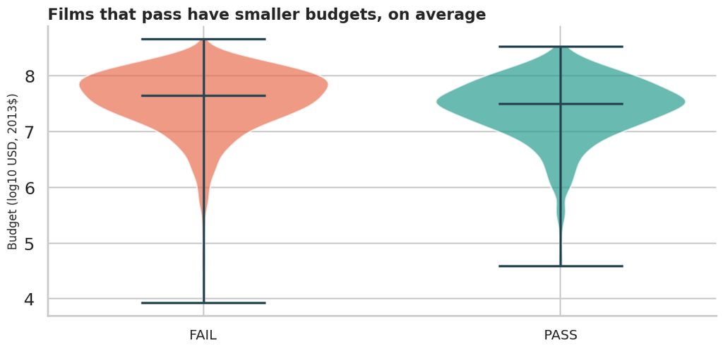

```
Median budget (FAIL): $44.0M
Median budget (PASS): $31.5M
```

```python
pass_budget = df[df['binary']=='PASS']['budget_2013$'].dropna()
fail_budget = df[df['binary']=='FAIL']['budget_2013$'].dropna()

fig, ax = plt.subplots(figsize=(10, 5))
parts = ax.violinplot([np.log10(fail_budget), np.log10(pass_budget)], positions=[0, 1], showmedians=True, widths=0.7)
for body, color in zip(parts['bodies'], [FAIL_COLOR, PASS_COLOR]):
    body.set_facecolor(color); body.set_alpha(0.7); body.set_edgecolor('white')
for key in ['cmedians', 'cbars', 'cmins', 'cmaxes']:
    parts[key].set_color(NEUTRAL)
ax.set_xticks([0, 1])
ax.set_xticklabels(['FAIL', 'PASS'], fontsize=13)
ax.set_ylabel('Budget (log10 USD, 2013$)')
ax.set_title('Films that pass have smaller budgets, on average', fontsize=15, loc='left', fontweight='bold')
ax.spines[['right', 'top']].set_visible(False)
plt.tight_layout()
plt.show()

print(f'Median budget (FAIL): ${fail_budget.median()/1e6:.1f}M')
print(f'Median budget (PASS): ${pass_budget.median()/1e6:.1f}M')
```

## 10. Q4, Does passing hurt the box office?

Failing films have larger budgets, so the fair comparison is return multiple, worldwide gross over budget.

```python
df['return_multiple'] = df['worldgross_2013$'] / df['budget_2013$']
clean = df.dropna(subset=['return_multiple','binary'])
clean = clean[clean['return_multiple'] < 100]

stats = clean.groupby('binary')['return_multiple'].agg(['median', 'mean', 'count']).round(2)
print(stats)
```

```
        median  mean  count
binary
FAIL      3.87  6.61    972
PASS      4.20  6.71    797
```

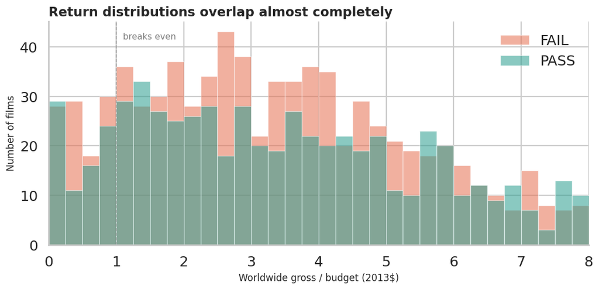

```python
fig, ax = plt.subplots(figsize=(10, 5))
bins = np.linspace(0, 8, 33)
for label, color in [('FAIL', FAIL_COLOR), ('PASS', PASS_COLOR)]:
    ax.hist(clean[clean['binary']==label]['return_multiple'], bins=bins, alpha=0.55, color=color, label=label, edgecolor='white', linewidth=0.8)
ax.axvline(1, color='gray', ls='--', lw=1, alpha=0.7)
ax.text(1.1, ax.get_ylim()[1]*0.92, 'breaks even', color='gray', fontsize=10)
ax.set_xlabel('Worldwide gross / budget (2013$)')
ax.set_ylabel('Number of films')
ax.set_title('Return distributions overlap almost completely', fontsize=15, loc='left', fontweight='bold')
ax.legend(frameon=False)
ax.spines[['right', 'top']].set_visible(False)
ax.set_xlim(0, 8)
plt.tight_layout()
plt.show()
```

## 11. Q5, Shape of the ROI distribution

Equal medians do not mean equal distributions, so I check the tails via quantiles.

```python
qs = [0.1, 0.25, 0.5, 0.75, 0.9, 0.95]
quantile_table = pd.DataFrame({label: clean[clean['binary']==label]['return_multiple'].quantile(qs).round(2) for label in ['PASS', 'FAIL']})
quantile_table.index = [f'{int(q*100)}th pct' for q in qs]
quantile_table
```

|  | PASS | FAIL |
| --- | --- | --- |
| 10th pct | 1.00 | 0.91 |
| 25th pct | 2.08 | 2.05 |
| 50th pct | 4.20 | 3.87 |
| 75th pct | 7.79 | 6.80 |
| 90th pct | 13.77 | 13.39 |
| 95th pct | 20.40 | 22.55 |

## 12. Q6, Why do films fail?

The five-level test breaks failure into casting, writing, and scripting issues.

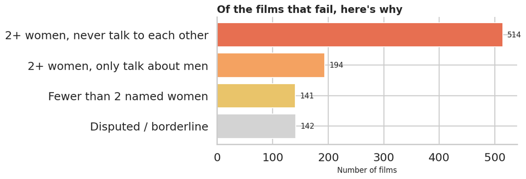

```
Of 991 failing films:
  2+ women, never talk to each other         514 films  (52%)
  2+ women, only talk about men              194 films  (20%)
  Fewer than 2 named women                   141 films  (14%)
  Disputed / borderline                      142 films  (14%)
```

```python
fail_reasons = (df[df['binary']=='FAIL']['clean_test'].value_counts().reindex(['notalk','men','nowomen','dubious']))

labels_pretty = {
    'nowomen': 'Fewer than 2 named women',
    'notalk':  '2+ women, never talk to each other',
    'men':     '2+ women, only talk about men',
    'dubious': 'Disputed / borderline',
}

fig, ax = plt.subplots(figsize=(11, 4))
ax.barh([labels_pretty[k] for k in fail_reasons.index], fail_reasons.values,
        color=[FAIL_COLOR, '#f4a261', '#e9c46a', 'lightgray'], edgecolor='white', linewidth=1.2)
for i, v in enumerate(fail_reasons.values):
    ax.text(v+8, i, f'{v:,}', va='center', fontsize=11)
ax.set_title("Of the films that fail, here's why", fontsize=15, loc='left', fontweight='bold')
ax.set_xlabel('Number of films')
ax.invert_yaxis()
ax.spines[['right', 'top']].set_visible(False)
plt.tight_layout()
plt.show()

n_fail = fail_reasons.sum()
print(f'\nOf {n_fail:,} failing films:')
for k, v in fail_reasons.items():
    print(f'  {labels_pretty[k]:<40}  {v:>4} films  ({v/n_fail:.0%})')
```

**Q6 answer.** The biggest failure mode is "the women never talk to each other" at 514 films, about 52% of failures. The cast is in place, but the women never share a scene with non-romantic dialogue.

## 13. Q7, Is the "two women" floor improving?

The yearly share of films with at least two named women, with the same 3-year rolling window as Q1.

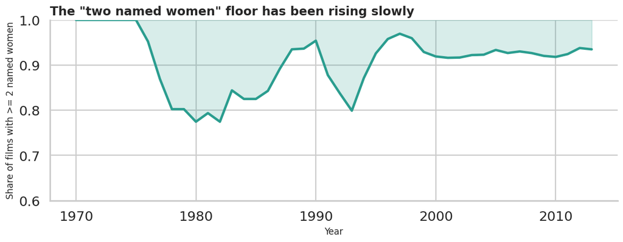

```python
df['has_two_women'] = df['clean_test'] != 'nowomen'
floor_yearly = (df.groupby('year')['has_two_women'].mean().rolling(3, center=True, min_periods=1).mean())

fig, ax = plt.subplots(figsize=(11, 4.5))
ax.fill_between(floor_yearly.index, floor_yearly.values, 1, color=PASS_COLOR, alpha=0.18)
ax.plot(floor_yearly.index, floor_yearly.values, color=PASS_COLOR, linewidth=3)
ax.set_ylim(0.6, 1.0)
ax.set_ylabel('Share of films with >= 2 named women')
ax.set_xlabel('Year')
ax.set_title('The "two named women" floor has been rising slowly', fontsize=15, loc='left', fontweight='bold')
ax.spines[['right', 'top']].set_visible(False)
plt.tight_layout()
plt.show()
```

**Q7 answer.** The floor rose from about 75% of films in the early 1980s to about 92% in the early 2010s. This is the most clearly improving sub-metric in the dataset.

## 14. Q8, Representation and money on one chart

```python
joint = (df.dropna(subset=['return_multiple']).groupby('decade')
           .agg(pass_rate=('binary', lambda s: (s=='PASS').mean()),
                median_roi=('return_multiple', 'median'),
                n=('binary', 'size')))
joint = joint[joint['n'] >= 30]
joint
```

| decade | pass_rate | median_roi | n |
| --- | --- | --- | --- |
| 1970 | 0.259259 | 14.449109 | 54 |
| 1980 | 0.288000 | 6.800160 | 125 |
| 1990 | 0.436202 | 4.268600 | 337 |
| 2000 | 0.486905 | 3.839414 | 840 |
| 2010 | 0.449772 | 3.732721 | 438 |

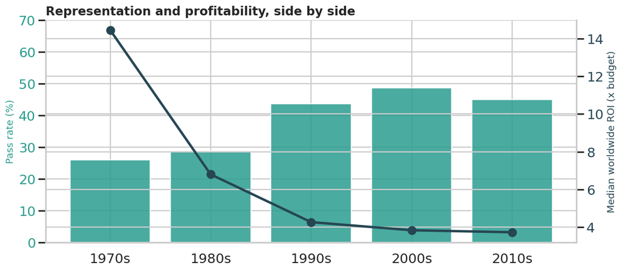

```python
fig, ax1 = plt.subplots(figsize=(11, 5))
ax1.bar(joint.index.astype(str)+'s', joint['pass_rate']*100, color=PASS_COLOR, alpha=0.85, edgecolor='white', label='Pass rate (%)')
ax1.set_ylabel('Pass rate (%)', color=PASS_COLOR, fontsize=12)
ax1.tick_params(axis='y', labelcolor=PASS_COLOR)
ax1.set_ylim(0, 70)
ax2 = ax1.twinx()
ax2.plot(joint.index.astype(str)+'s', joint['median_roi'], '-o', color=NEUTRAL, linewidth=3, markersize=10, label='Median ROI multiple')
ax2.set_ylabel('Median worldwide ROI (x budget)', color=NEUTRAL, fontsize=12)
ax2.tick_params(axis='y', labelcolor=NEUTRAL)
ax2.spines['top'].set_visible(False)
ax1.spines[['top']].set_visible(False)
ax1.set_title('Representation and profitability, side by side', fontsize=15, loc='left', fontweight='bold')
plt.tight_layout()
plt.show()
```

## 15. Insights

**Limitations.** Bechdel is coarse, the data ends in 2013, the 1970s sample is sparse, and nothing here is causal.

## 16. Conclusion

Pass rate has improved slowly across 44 years, and the "audiences vote against it" claim is not borne out in the data. More than half of failing films already have two or more named women cast, the women just do not talk to each other, so this is a writers'-room problem, not a casting one.

*Min Liu, DS 220 Project II, Spring 2026. Data from FiveThirtyEight.*